# In-class Exercise 6

In this exercise, I learnt how to handle and visualise geospatial data with R.

Sia Heng Guang https://www.linkedin.com/in/hengguang/ (MITB Analytics Track)https://scis.smu.edu.sg/  
2022-02-26

## Installing relevant libraries

```r
packages = c('readr', 'sf', 'tmap', 'tidyverse', 'tidyr', 'dplyr')
for (p in packages){
  if(!require(p, character.only = T)){
    install.packages(p)
  }
  library(p,character.only = T)
}
```

## Mapping Geospatial Point Data using R

### Importing and examining data

```r
sgpools <- read_csv("data/aspatial/SGPools_svy21.csv")
```

We can use the st_as_sf() function of the sf packages to convert the sgpools dataframe into a simple feature data frame, using the x and y coordinates. The **crs** argument requires to put the coordinate system in Singapore’s SVY21 coordinate system, which can be found on epsg.io.

```r
sgpools_sf <- st_as_sf(
  sgpools,
  coords = c("XCOORD",
             "YCOORD"),
             crs= 3414)
```

### Plotting point symbols onto the map

The code chunk below is used to create an interactive point symbol map.

- tmap_mode() is used to switch the display from static mode (i.e. “plot”) to interactive mode (i.e. “view”).
- tm_shape() is used to create a tmap-element that specifies a spatial data object (i.e. point).
- tm_bubble() is used to create a tmap-element that draws bubbles or small dots. Both colors and sizes of the bubbles can be mapped to data variables.

```r
tmap_mode("view")
tm_shape(sgpools_sf)+
tm_bubbles(col = "red",
           size = 1,
           border.col = "black",
           border.lwd = 1)
```

[interactive chart not shown]

To make the symbols proportionate, we need to assign a numerical variable to the size visual attribute.

```r
tm_shape(sgpools_sf)+
tm_bubbles(col = "red",
           size = "Gp1Gp2 Winnings",
           border.col = "black",
           border.lwd = 0.5)
```

[interactive chart not shown]

We can also apply colour attributes to the type of outlet.

```r
tm_shape(sgpools_sf)+
tm_bubbles(col = "OUTLET TYPE",
          size = "Gp1Gp2 Winnings",
          border.col = "black",
          border.lwd = 0.5)
```

[interactive chart not shown]

Tmap also allows faceted plots, which produces multiple maps and synchronised zoom and pan settings.

```r
tm_shape(sgpools_sf) +
  tm_bubbles(col = "OUTLET TYPE",
          size = "Gp1Gp2 Winnings",
          border.col = "black",
          border.lwd = 1) +
  tm_facets(by= "OUTLET TYPE",
            nrow = 1,
            sync = TRUE)
```

[interactive chart not shown]

## Choropleth Mapping with R

We will learn:

- to import an aspatial data in R by using readr pakage,
- to import geospatial data (ESRI shapefile) into R as simple feature objects using sf package,
- to perform data wrangling using dplyr and tidyr packages,
- to plot choropleth maps using tmap package.

### Importing and examining data

URA Master Plan subzone boundary will be used in shapefile format based on URA Master Plan 2014.

Singapore Residents by Planning area does not have any geospatial data but contains Planning Area and Subzone values which can be used as unique identifiers.

```r
mpsz <- st_read(dsn = "data/geospatial",
                layer = "MP14_SUBZONE_WEB_PL")
```

We can import attribute data respopagsex2000to2018 using the read_csv() function.

```r
popagsex <- read_csv("data/aspatial/respopagsex2000to2018.csv")
```

After assigning it to a variable, we can do some data preparation:

- Extracting 2018 records only
- Extracting Male records only
- Deriving new variables, Young, Economically Active and Aged

```r
popagsex2018_male <- popagsex %>%
  filter(Sex == "Males") %>%
  filter(Time == 2018) %>%
  spread(AG, Pop) %>%
  mutate(YOUNG = `0_to_4`+`5_to_9`+`10_to_14`+
`15_to_19`+`20_to_24`) %>%
mutate(`ECONOMY ACTIVE` = rowSums(.[9:13])+
rowSums(.[15:17]))%>%
mutate(`AGED`=rowSums(.[18:22])) %>%
mutate(`TOTAL`=rowSums(.[5:22])) %>%
mutate(`DEPENDENCY` = (`YOUNG` + `AGED`)
/`ECONOMY ACTIVE`) %>%
mutate_at(.vars = vars(PA, SZ),
          .funs = funs(toupper)) %>%
  select(`PA`, `SZ`, `YOUNG`,
         `ECONOMY ACTIVE`, `AGED`,
         `TOTAL`, `DEPENDENCY`) %>%
  filter(`ECONOMY ACTIVE` > 0)
```

Next, we use left_join to join the geospatial data and the attribute table using the SZ as the common identifier.

```r
mpsz_agemale2018 <- left_join(mpsz,
                              popagsex2018_male,
                              by = c("SUBZONE_N" = "SZ"))
```

### Plotting the map

The chunk below plots a basic choropleth map.

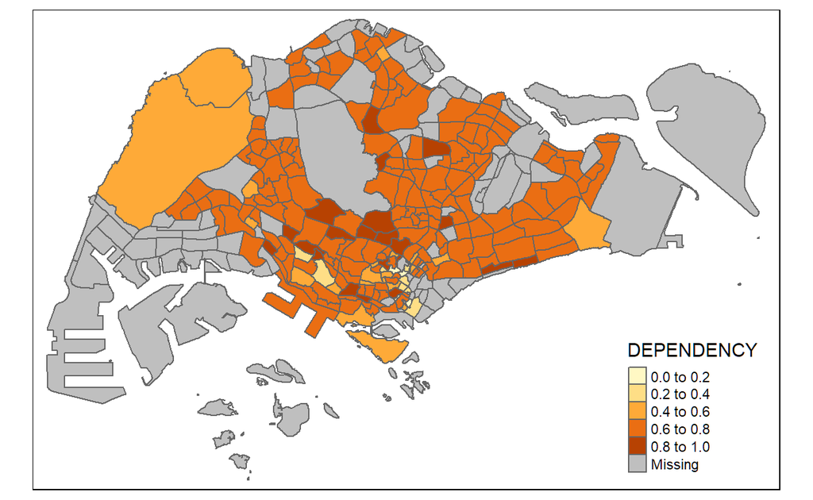

```r
tmap_mode("plot")
qtm(mpsz_agemale2018,
    fill = "DEPENDENCY")
```

We can also use tmap() to customise the plot further. The code chunk below shows the basic input data required to plot the subzone polygons.

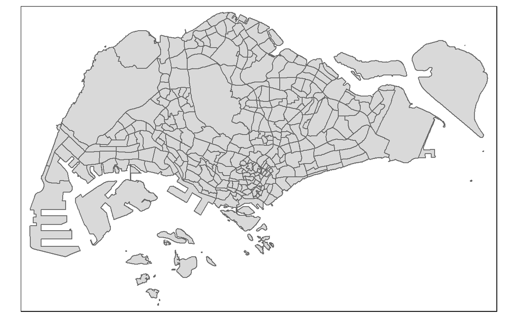

```r
tm_shape(mpsz_agemale2018) +
  tm_polygons()
```

We can use a selected variable to show the distribution.

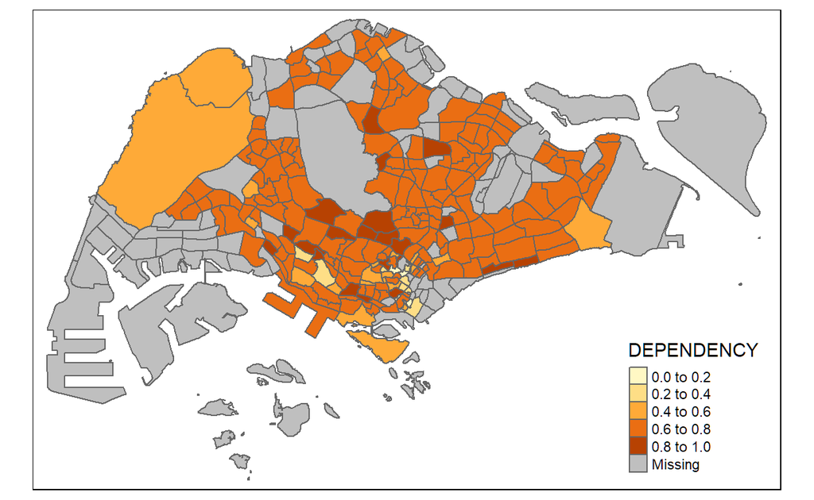

```r
tm_shape(mpsz_agemale2018)+
  tm_polygons("DEPENDENCY")
```

We can take note of the following:

If we use the tm_fill instead of tm_polygons, we can see the data without the polygons boundary. We can customise other attributes further if we do this.

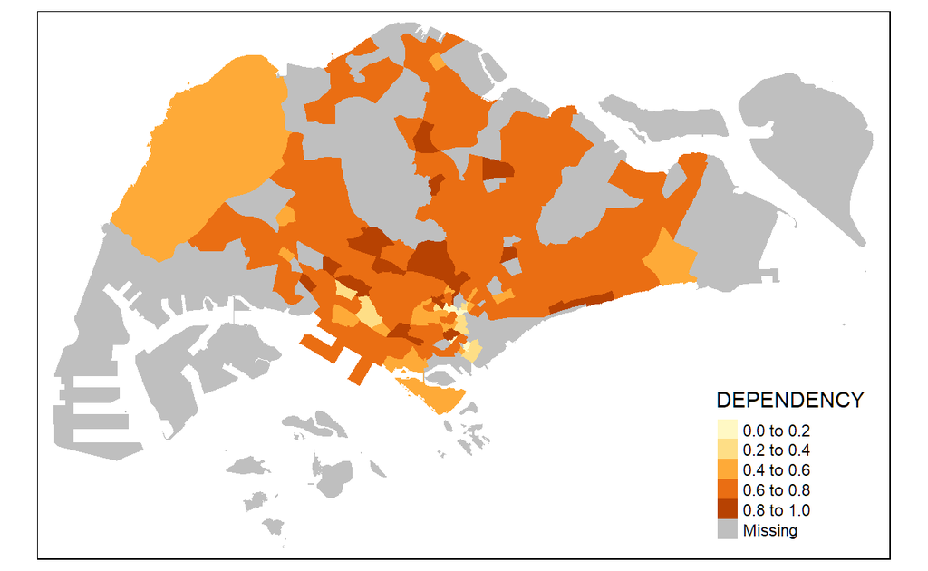

```r
tm_shape(mpsz_agemale2018)+
  tm_fill("DEPENDENCY")
```

We draw in the borders of the subzones using the tm_borders:

- lwd = border line width. The default is 1,
- alpha = transparency number between 0 (totally transparent) and 1 (not transparent). By default, the alpha value of the col is used (normally 1),
- col = border colour, and
- lty = border line type. The default is “solid”.

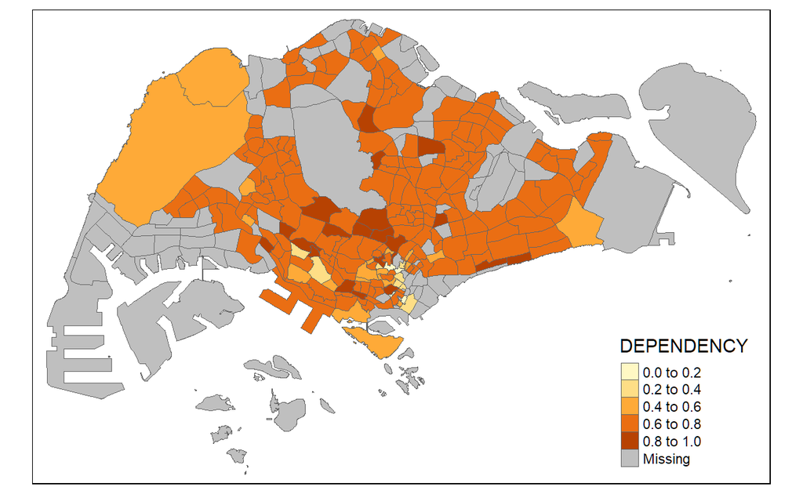

```r
tm_shape(mpsz_agemale2018)+
  tm_fill("DEPENDENCY") +
  tm_borders(lwd = 0.1,
             alpha = 1)
```

Choropleth maps employ some method of data classification, and then group them into certain data ranges.

tmap provides a total ten data classification methods, namely: fixed, sd, equal, pretty (default), quantile, kmeans, hclust, bclust, fisher, and jenks. We use the style argument of the tm_fill() or tm_polygons().

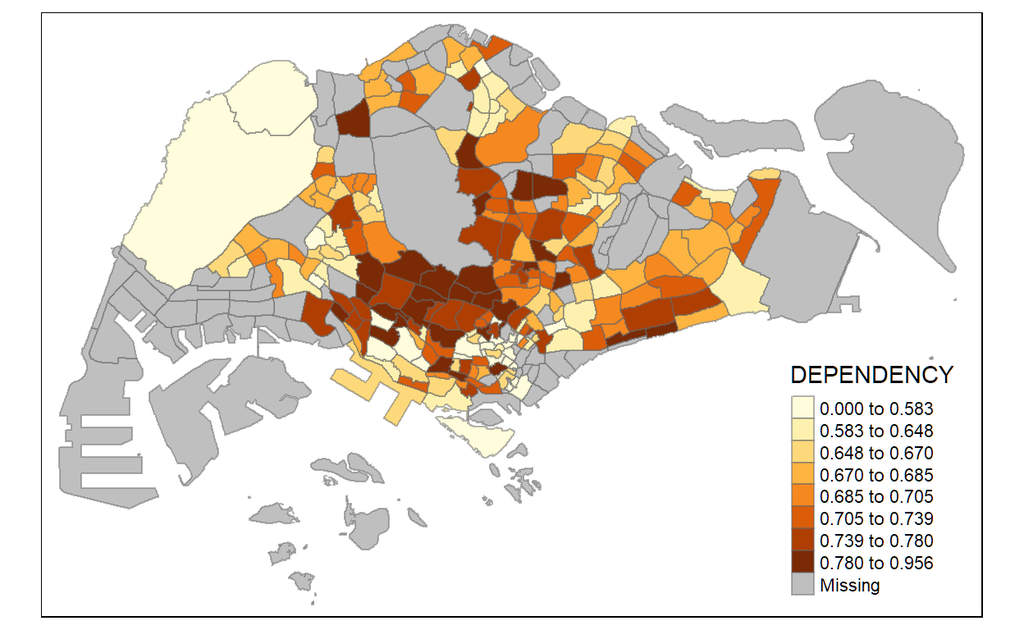

```r
tm_shape(mpsz_agemale2018)+
  tm_fill("DEPENDENCY",
          n = 8,
          style = "quantile") +
  tm_borders(alpha = 0.5)
```

tmap also supports predefined colour ramps from RColorBrewer, which we can use the palette argument of tm_fill().

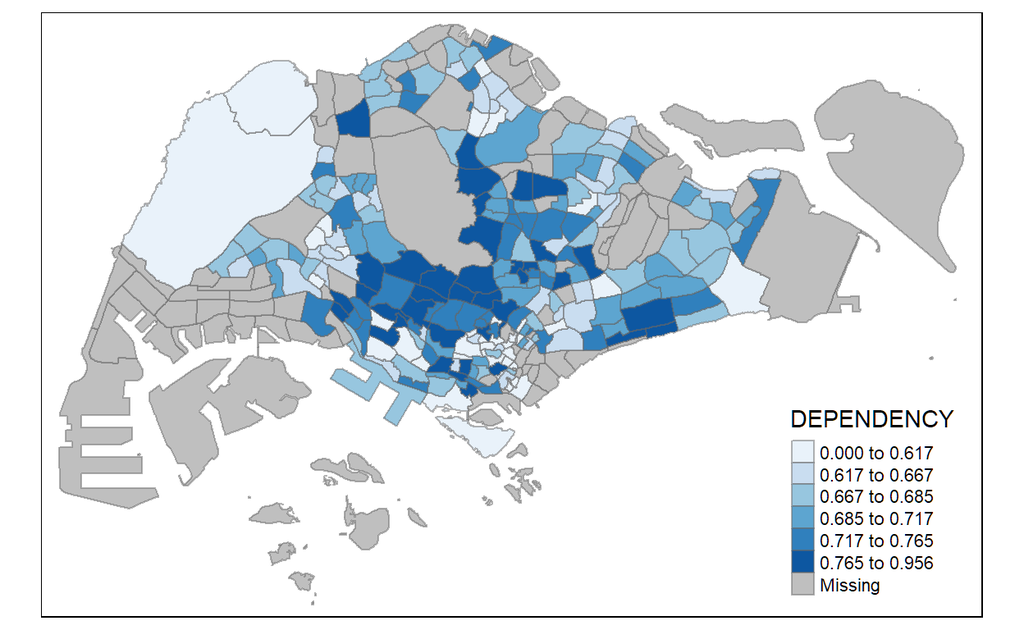

```r
tm_shape(mpsz_agemale2018)+
  tm_fill("DEPENDENCY",
          n = 6,
          style = "quantile",
          palette = "Blues") +
  tm_borders(alpha = 0.5)
```

We can also reverse the colour shading by adding a “-” prefix.

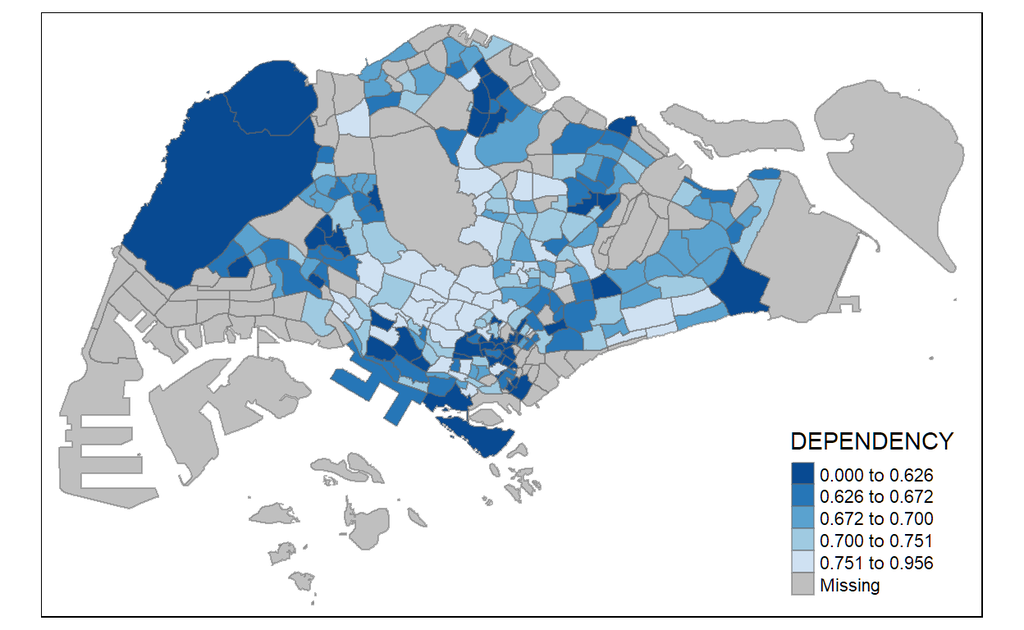

```r
tm_shape(mpsz_agemale2018)+
  tm_fill("DEPENDENCY",
          style = "quantile",
          palette = "-Blues") +
  tm_borders(alpha = 0.5)
```

We can also include a legend.

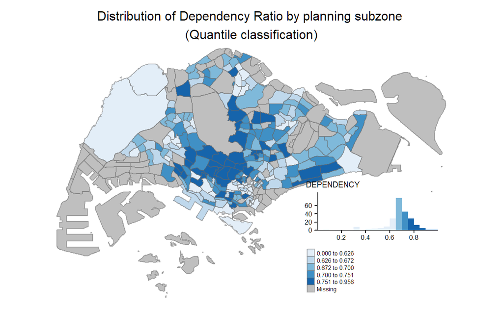

```r
tm_shape(mpsz_agemale2018)+
  tm_fill("DEPENDENCY",
          style = "quantile",
          palette = "Blues",
          legend.hist = TRUE,
          legend.is.portrait = TRUE,
          legend.hist.z = 0.1) +
  tm_layout(main.title = "Distribution of Dependency Ratio by planning subzone \n(Quantile classification)",
            main.title.position = "center",
            main.title.size = 1,
            legend.height = 0.45,
            legend.width = 0.35,
            legend.outside = FALSE,
            legend.position = c("right", "bottom"),
            frame = FALSE) +
  tm_borders(alpha = 0.5)
```

tmap also has different layout settings which can be called using tmap_style().

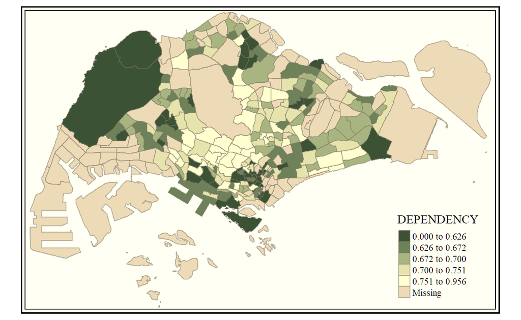

```r
tm_shape(mpsz_agemale2018)+
  tm_fill("DEPENDENCY",
          style = "quantile",
          palette = "-Greens") +
  tm_borders(alpha = 0.5) +
  tmap_style("classic")
```

In the code chunk below, tm_compass(), tm_scale_bar() and tm_grid() are used to add compass, scale bar and grid lines onto the choropleth map.

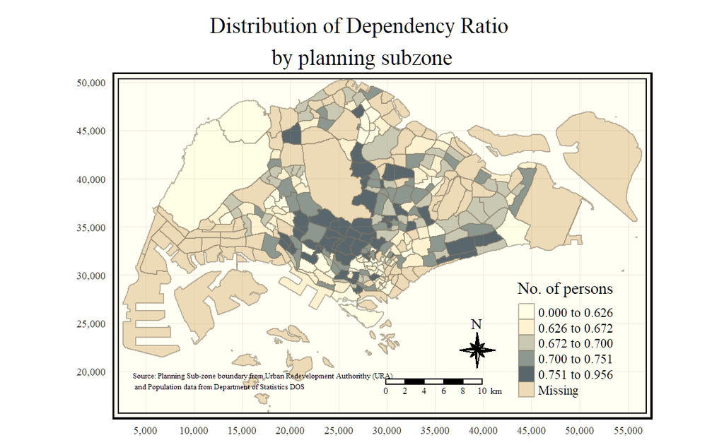

```r
tm_shape(mpsz_agemale2018)+
  tm_fill("DEPENDENCY",
          style = "quantile",
          palette = "Blues",
          title = "No. of persons") +
  tm_layout(main.title = "Distribution of Dependency Ratio \nby planning subzone",
            main.title.position = "center",
            main.title.size = 1.2,
            legend.height = 0.45,
            legend.width = 0.35,
            frame = TRUE) +
  tm_borders(alpha = 0.5) +
  tm_compass(type="8star", size = 2) +
  tm_scale_bar(width = 0.15) +
  tm_grid(lwd = 0.1, alpha = 0.2) +
  tm_credits("Source: Planning Sub-zone boundary from Urban Redevelopment Authorithy (URA)\n and Population data from Department of Statistics DOS",
             position = c("left", "bottom"))
```

To reset back to the default style, we can use the “white” style.

```r
tmap_style("white")
```

### Multiple small choropleth maps

We can use facet maps to compose maps side by side or stacked vertically.

In tmap, small multiple maps can be plotted in three ways:

- by assigning multiple values to at least one of the asthetic arguments,
- by defining a group-by variable in tm_facets(), and
- by creating multiple stand-alone maps with tmap_arrange().

We define the ncols in tm_fill() using a vector:

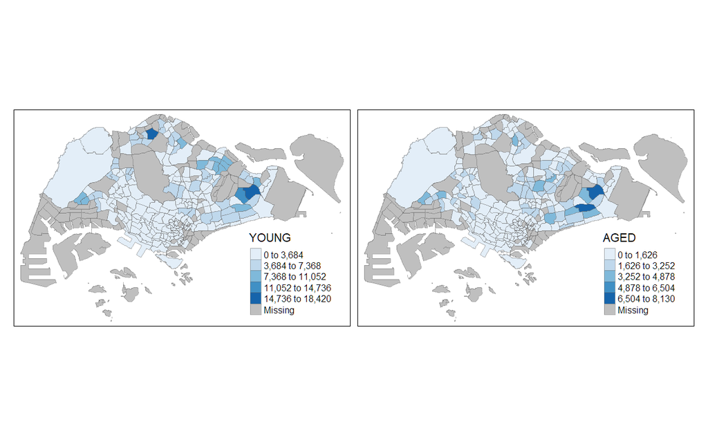

```r
tm_shape(mpsz_agemale2018)+
  tm_fill(c("YOUNG", "AGED"),
          style = "equal",
          palette = "Blues") +
  tm_layout(legend.position = c("right",
                                "bottom")) +
  tm_borders(alpha = 0.5) +
  tmap_style("white")
```